# Data Dictionary

- **order_id:** Unique ID of the order
- **customer_id**: ID of the customer who ordered the food
- **restaurant_name:** Name of the restaurant
- **cuisine_type**: Cuisine ordered by the customer
- **cost**: Cost of the order
- **day_of_the_week**: Indicates whether the order is placed on a weekday or weekend (The weekday is from Monday to Friday and the weekend is Saturday and Sunday)
- **rating**: Rating given by the customer out of 5
- **food_preparation_time**: Time (in minutes) taken by the restaurant to prepare the food. This is calculated by taking the difference between the timestamps of the restaurant's order confirmation and the delivery person's pick-up confirmation.
- **delivery_time**: Time (in minutes) taken by the delivery person to deliver the food package. This is calculated by taking the difference between the timestamps of the delivery person's pick-up confirmation and drop-off information

```python
import numpy as np
import pandas as pd
import matplotlib.pyplot as plt
import seaborn as sns
```

```python
from google.colab import drive
drive.mount('/content/drive')
```

```python
df = "/content/drive/MyDrive/foodhub_order.csv"
df = pd.read_csv(df)
df
```

|  | order_id | customer_id | restaurant_name | cuisine_type | cost_of_the_order | day_of_the_week | rating | food_preparation_time | delivery_time |
| --- | --- | --- | --- | --- | --- | --- | --- | --- | --- |
| 0 | 1477147 | 337525 | Hangawi | Korean | 30.75 | Weekend | Not given | 25 | 20 |
| 1 | 1477685 | 358141 | Blue Ribbon Sushi Izakaya | Japanese | 12.08 | Weekend | Not given | 25 | 23 |
| 2 | 1477070 | 66393 | Cafe Habana | Mexican | 12.23 | Weekday | 5 | 23 | 28 |
| 3 | 1477334 | 106968 | Blue Ribbon Fried Chicken | American | 29.20 | Weekend | 3 | 25 | 15 |
| 4 | 1478249 | 76942 | Dirty Bird to Go | American | 11.59 | Weekday | 4 | 25 | 24 |
| ... | ... | ... | ... | ... | ... | ... | ... | ... | ... |
| 1893 | 1476701 | 292602 | Chipotle Mexican Grill $1.99 Delivery | Mexican | 22.31 | Weekend | 5 | 31 | 17 |
| 1894 | 1477421 | 397537 | The Smile | American | 12.18 | Weekend | 5 | 31 | 19 |
| 1895 | 1477819 | 35309 | Blue Ribbon Sushi | Japanese | 25.22 | Weekday | Not given | 31 | 24 |
| 1896 | 1477513 | 64151 | Jack's Wife Freda | Mediterranean | 12.18 | Weekday | 5 | 23 | 31 |
| 1897 | 1478056 | 120353 | Blue Ribbon Sushi | Japanese | 19.45 | Weekend | Not given | 28 | 24 |

1898 rows × 9 columns

```python
df.head()
```

|  | order_id | customer_id | restaurant_name | cuisine_type | cost_of_the_order | day_of_the_week | rating | food_preparation_time | delivery_time |
| --- | --- | --- | --- | --- | --- | --- | --- | --- | --- |
| 0 | 1477147 | 337525 | Hangawi | Korean | 30.75 | Weekend | Not given | 25 | 20 |
| 1 | 1477685 | 358141 | Blue Ribbon Sushi Izakaya | Japanese | 12.08 | Weekend | Not given | 25 | 23 |
| 2 | 1477070 | 66393 | Cafe Habana | Mexican | 12.23 | Weekday | 5 | 23 | 28 |
| 3 | 1477334 | 106968 | Blue Ribbon Fried Chicken | American | 29.20 | Weekend | 3 | 25 | 15 |
| 4 | 1478249 | 76942 | Dirty Bird to Go | American | 11.59 | Weekday | 4 | 25 | 24 |

```python
print("There are", df.shape[0], 'rows and', df.shape[1], "columns.")
```

```
There are 1898 rows and 9 columns.
```

```python
df.info()
```

```
<class 'pandas.core.frame.DataFrame'>
RangeIndex: 1898 entries, 0 to 1897
Data columns (total 9 columns):
 #   Column                 Non-Null Count  Dtype
---  ------                 --------------  -----
 0   order_id               1898 non-null   int64
 1   customer_id            1898 non-null   int64
 2   restaurant_name        1898 non-null   object
 3   cuisine_type           1898 non-null   object
 4   cost_of_the_order      1898 non-null   float64
 5   day_of_the_week        1898 non-null   object
 6   rating                 1898 non-null   object
 7   food_preparation_time  1898 non-null   int64
 8   delivery_time          1898 non-null   int64
dtypes: float64(1), int64(4), object(4)
memory usage: 133.6+ KB
```

- There are 5 numerical columns in the data and 4 object type columns.
- Rating is read as object type column but it should be a numerical column.
- We observe that all columns have 1898 rows which indicates there are no missing values in the data. We can also check that by the code below:

```python
df.isnull().sum()
```

```
order_id                 0
customer_id              0
restaurant_name          0
cuisine_type             0
cost_of_the_order        0
day_of_the_week          0
rating                   0
food_preparation_time    0
delivery_time            0
dtype: int64
```

```python
df.describe()
```

|  | order_id | customer_id | cost_of_the_order | food_preparation_time | delivery_time |
| --- | --- | --- | --- | --- | --- |
| count | 1898.000 | 1898.000 | 1898.000 | 1898.000 | 1898.000 |
| mean | 1477495.500 | 171168.478 | 16.499 | 27.372 | 24.162 |
| std | 548.050 | 113698.140 | 7.484 | 4.632 | 4.973 |
| min | 1476547.000 | 1311.000 | 4.470 | 20.000 | 15.000 |
| 25% | 1477021.250 | 77787.750 | 12.080 | 23.000 | 20.000 |
| 50% | 1477495.500 | 128600.000 | 14.140 | 27.000 | 25.000 |
| 75% | 1477969.750 | 270525.000 | 22.297 | 31.000 | 28.000 |
| max | 1478444.000 | 405334.000 | 35.410 | 35.000 | 33.000 |

```python
df['food_preparation_time'].describe()
```

```
count    1898.000000
mean       27.371970
std         4.632481
min        20.000000
25%        23.000000
50%        27.000000
75%        31.000000
max        35.000000
Name: food_preparation_time, dtype: float64
```

- We can see that the minimum amount of time to prepare food takes about 20 minutes while the average and the maximum amout of time to prepare food are 27.4 and 35 minutes repectively.

```python
df['rating'].value_counts()
```

```
Not given    736
5            588
4            386
3            188
Name: rating, dtype: int64
```

- There are 736 that are not rated. We should replace the "Not given" value to be read as missing value (NaN) and change the data type to float.

```python
df['rating'] = df['rating'].replace(['Not given'],np.nan)
df['rating'] = df['rating'].astype(float)
df.info()
```

```
<class 'pandas.core.frame.DataFrame'>
RangeIndex: 1898 entries, 0 to 1897
Data columns (total 9 columns):
 #   Column                 Non-Null Count  Dtype
---  ------                 --------------  -----
 0   order_id               1898 non-null   int64
 1   customer_id            1898 non-null   int64
 2   restaurant_name        1898 non-null   object
 3   cuisine_type           1898 non-null   object
 4   cost_of_the_order      1898 non-null   float64
 5   day_of_the_week        1898 non-null   object
 6   rating                 1162 non-null   float64
 7   food_preparation_time  1898 non-null   int64
 8   delivery_time          1898 non-null   int64
dtypes: float64(2), int64(4), object(3)
memory usage: 133.6+ KB
```

```python
df.describe()
```

|  | order_id | customer_id | cost_of_the_order | rating | food_preparation_time | delivery_time |
| --- | --- | --- | --- | --- | --- | --- |
| count | 1898.000 | 1898.000 | 1898.000 | 1162.000 | 1898.000 | 1898.000 |
| mean | 1477495.500 | 171168.478 | 16.499 | 4.344 | 27.372 | 24.162 |
| std | 548.050 | 113698.140 | 7.484 | 0.741 | 4.632 | 4.973 |
| min | 1476547.000 | 1311.000 | 4.470 | 3.000 | 20.000 | 15.000 |
| 25% | 1477021.250 | 77787.750 | 12.080 | 4.000 | 23.000 | 20.000 |
| 50% | 1477495.500 | 128600.000 | 14.140 | 5.000 | 27.000 | 25.000 |
| 75% | 1477969.750 | 270525.000 | 22.297 | 5.000 | 31.000 | 28.000 |
| max | 1478444.000 | 405334.000 | 35.410 | 5.000 | 35.000 | 33.000 |

**Observation on Cost**

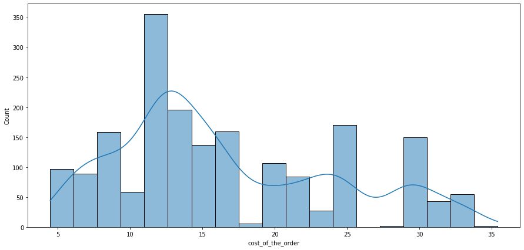

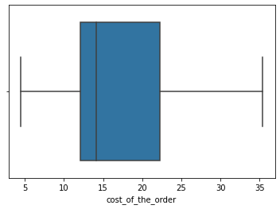

```python
plt.figure(figsize=(15, 7))
sns.histplot(data=df,x='cost_of_the_order',kde=True);
plt.show()
sns.boxplot(data=df,x='cost_of_the_order')
plt.show()
```

- The distribution of cost of the orders is skewed towards the right.
- There are no outliers in this variable.
- The cost order ranges from 4 to 35.4 dollars.
- The median cost is around 14 dollars.

**Observation on Rating**

[figure not shown]

```python
sns.histplot(data=df,x='rating')
plt.show()
```

**Observation on Day of the week**

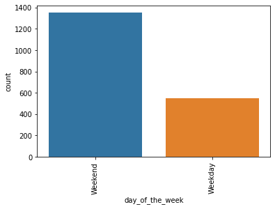

```python
sns.countplot(data=df,x='day_of_the_week')
plt.xticks(rotation=90)
plt.show()
```

- More orders were placed on the weekends compared to on the weekdays.

**Observation on Food preparation time**

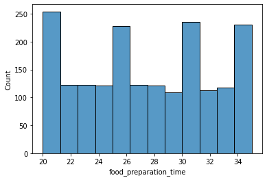

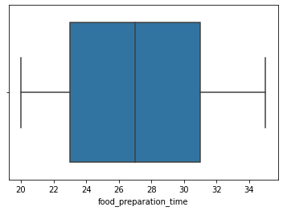

```python
sns.histplot(data=df,x='food_preparation_time')
plt.show()
sns.boxplot(data=df,x='food_preparation_time')
plt.show()
```

**Observation on Cuisine Type**

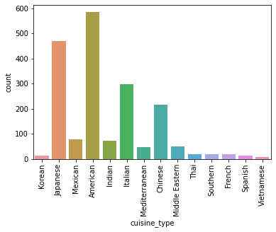

```python
sns.countplot(data=df,x='cuisine_type')
plt.xticks(rotation=90)
plt.show()
```

- American cuisine is the most popular cuisine followed by Japanese and Italian.
- Vitnamese cusine is ranked the least popular.

**Observation on Delivery time**

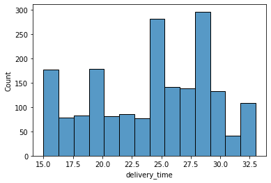

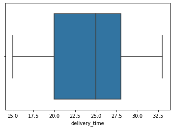

```python
sns.histplot(data=df,x='delivery_time')
plt.show()
sns.boxplot(data=df,x='delivery_time')
plt.show()
```

```python
list_col = ['restaurant_name', 'cuisine_type', 'day_of_the_week']
for column in list_col:
  print(df[column].value_counts())
  print("-"*50)
```

```
Shake Shack                  219
The Meatball Shop            132
Blue Ribbon Sushi            119
Blue Ribbon Fried Chicken     96
Parm                          68
                            ...
Sushi Choshi                   1
Dos Caminos Soho               1
La Follia                      1
Philippe Chow                  1
'wichcraft                     1
Name: restaurant_name, Length: 178, dtype: int64
--------------------------------------------------
American          584
Japanese          470
Italian           298
Chinese           215
Mexican            77
Indian             73
Middle Eastern     49
Mediterranean      46
Thai               19
French             18
Southern           17
Korean             13
Spanish            12
Vietnamese          7
Name: cuisine_type, dtype: int64
--------------------------------------------------
Weekend    1351
Weekday     547
Name: day_of_the_week, dtype: int64
--------------------------------------------------
```

- The top five restaurants in terms of number of orders received are:
1. Shake Shack
2. The Meatball Shop
3. Blue Ribbon Susshi
4. Blue Ribbon Fried Chicken
5. Parm

```python
df.groupby(['cuisine_type','day_of_the_week'])['cuisine_type'].count().sort_values(ascending=False)
```

```
cuisine_type    day_of_the_week
American        Weekend            415
Japanese        Weekend            335
Italian         Weekend            207
American        Weekday            169
Chinese         Weekend            163
Japanese        Weekday            135
Italian         Weekday             91
Mexican         Weekend             53
Chinese         Weekday             52
Indian          Weekend             49
Middle Eastern  Weekend             32
Mediterranean   Weekend             32
Mexican         Weekday             24
Indian          Weekday             24
Middle Eastern  Weekday             17
Thai            Weekend             15
Mediterranean   Weekday             14
French          Weekend             13
Korean          Weekend             11
Southern        Weekend             11
Spanish         Weekend             11
Southern        Weekday              6
French          Weekday              5
Thai            Weekday              4
Vietnamese      Weekend              4
                Weekday              3
Korean          Weekday              2
Spanish         Weekday              1
Name: cuisine_type, dtype: int64
```

- American Cuisine is the most popular cuisine order on weekends

```python
cost_perc = df.loc[df['cost_of_the_order']>20,'cost_of_the_order'].count()/df['cost_of_the_order'].count()
cost_perc * 100
```

```
29.24130663856691
```

- 29.2 percent of the orders cost more than 20 dollars.

```python
df['delivery_time'].mean()
```

```
24.161749209694417
```

- Mean order delivery time is 24.16 minutes

```python
df['customer_id'].value_counts().head(3)
```

```
52832    13
47440    10
83287     9
Name: customer_id, dtype: int64
```

- The top three most frequent customers by order IDs are:
- 52832 - 13 orders
- 47440 - 10 orders
- 83287- 9 orders

**1. Analysis on Delivery time and Day of the week.**

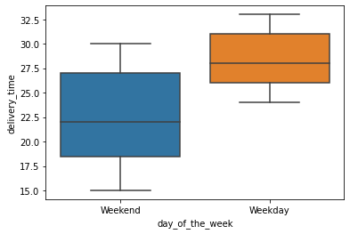

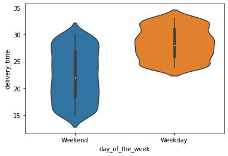

```python
sns.boxplot(data=df,x='day_of_the_week',y='delivery_time')
plt.show()
sns.violinplot(data=df, x='day_of_the_week', y='delivery_time', orient='v');
```

- We can see that it takes more time to deliver orders on weekdays compared to weekends.

**2. Analysis on Cuisine type and Cost of the order.**

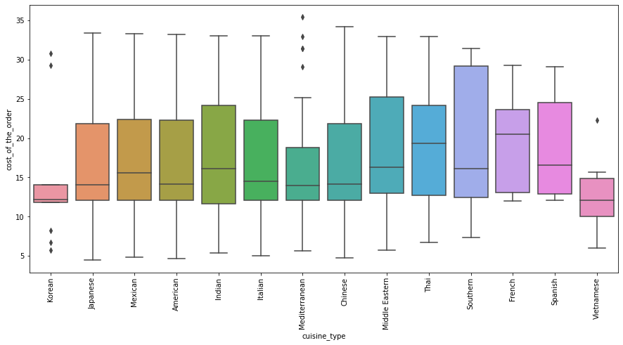

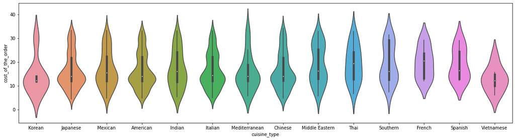

```python
plt.figure(figsize=(15,7))
sns.boxplot(data=df,x='cuisine_type',y='cost_of_the_order')
plt.xticks(rotation=90)
plt.show()
plt.figure(figsize=(20,5))
sns.violinplot(data=df, x='cuisine_type', y='cost_of_the_order');
```